# Chapter 1: Data Visualization with ggplot2

Akil Elkamel

6/8/2020

## Importing packages

In this chapter, we will use the package tidyverse.

So by loading tidyverse, the following packages will be loaded: ggplot2, tibble, tidyr, readr, purrr, and dplyr.

```r
library(tidyverse)
```

## The **mpg** dataset

```r
mpg
```

```
## # A tibble: 234 x 11
##    manufacturer model    displ  year   cyl trans   drv     cty   hwy fl    class
##    <chr>        <chr>    <dbl> <int> <int> <chr>   <chr> <int> <int> <chr> <chr>
##  1 audi         a4         1.8  1999     4 auto(l~ f        18    29 p     comp~
##  2 audi         a4         1.8  1999     4 manual~ f        21    29 p     comp~
##  3 audi         a4         2    2008     4 manual~ f        20    31 p     comp~
##  4 audi         a4         2    2008     4 auto(a~ f        21    30 p     comp~
##  5 audi         a4         2.8  1999     6 auto(l~ f        16    26 p     comp~
##  6 audi         a4         2.8  1999     6 manual~ f        18    26 p     comp~
##  7 audi         a4         3.1  2008     6 auto(a~ f        18    27 p     comp~
##  8 audi         a4 quat~   1.8  1999     4 manual~ 4        18    26 p     comp~
##  9 audi         a4 quat~   1.8  1999     4 auto(l~ 4        16    25 p     comp~
## 10 audi         a4 quat~   2    2008     4 manual~ 4        20    28 p     comp~
## # ... with 224 more rows
```

As shown above the **mpg** dataset is stored in the form of a tibble which is a modern reimagining of the data.frame. **mpg** is composed by 234 observations (in the rows) and 11 variables (in the columns). It contains observations collected by the US Environment Protection Agency on 38 models of cars.

The variables of the **mpg** dataset are as follow:

1. manufacturer: manufacturer name
2. model: model name
3. displ: engine displacement, in litres
4. year:year of manufacture
5. cyl: number of cylinders
6. trans: type of transmission
7. drv: the type of drive train, where f = front-wheel drive, r = rear wheel drive, 4 = 4wd
8. cty: city miles per gallon
9. hwy: highway miles per gallon
10. fl: fuel type
11. class: “type” of car

## Visual exploration of the dataset

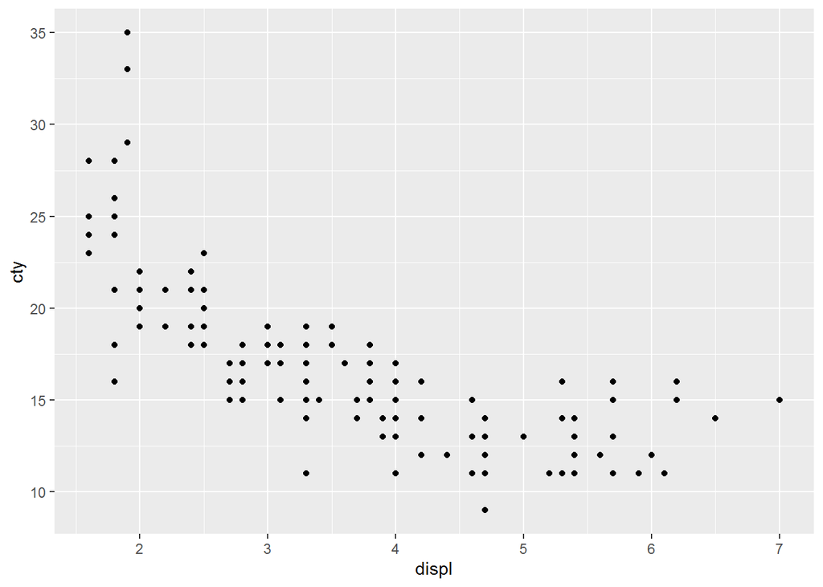

```r
ggplot(data = mpg) +
    geom_point(mapping = aes(x = displ, y = cty))
```

The plot shows a negative relationship between engine size (displ) and fuel efficiency (cty). In other words, cars with big engines use more fuel inside the city.

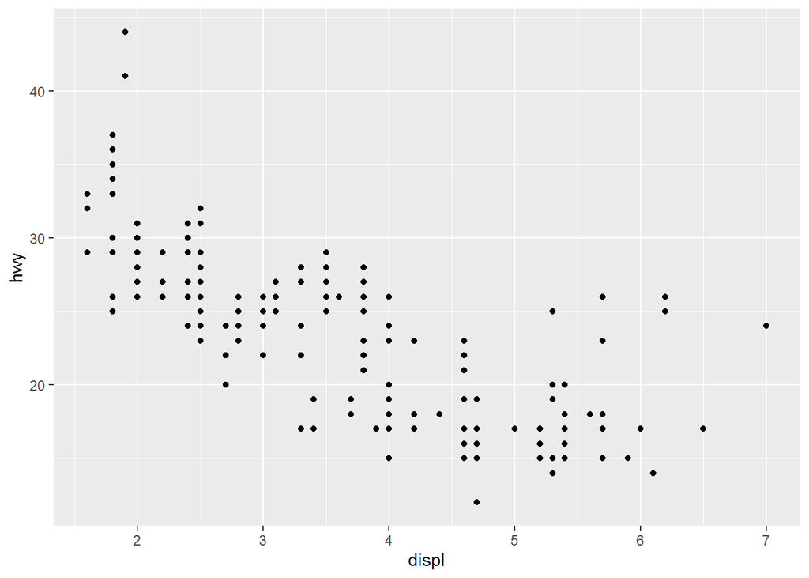

```r
ggplot(data = mpg) +
    geom_point(mapping = aes(x = displ, y = hwy))
```

The plot shows a negative relationship between engine size (displ) and fuel efficiency (hwy). In other words, cars with big engines use more fuel on the highway.

Both above plots confirm the hypothesis about fuel efficiency and engine size. Which is “*The higher the engine size., the lower the fuel efficiency.*” and this inside the city and on the highway.

The following plot shows the engine size **displ** versus the highway miles per gallon **hwy**. The data points are colored by the number of cylinders **cyl**.

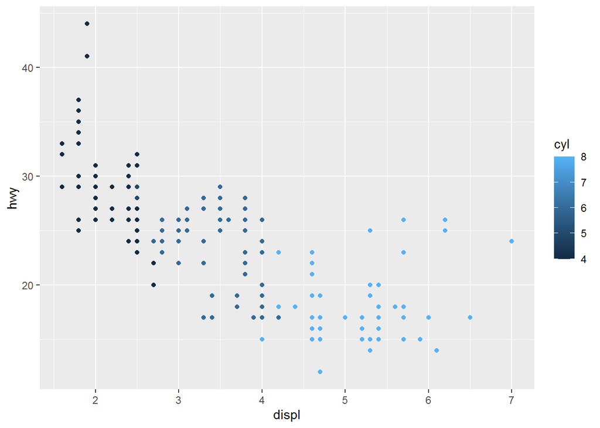

```r
ggplot(data = mpg) +
    geom_point(mapping = aes(x = displ, y = hwy, color = cyl))
```

To more distinguish the cars by the number of cylinders we can transform it as factor.

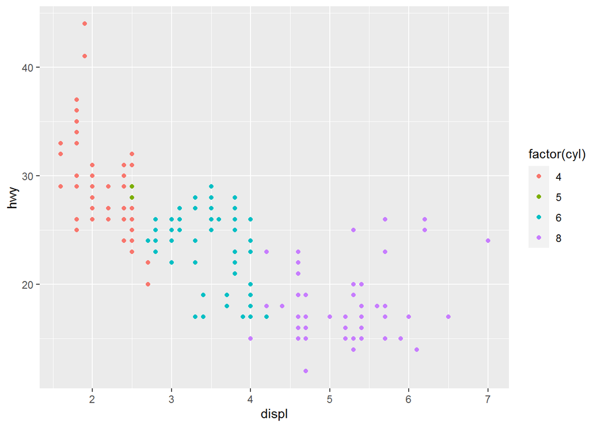

```r
ggplot(data = mpg) +
    geom_point(mapping = aes(x = displ, y = hwy, color = factor(cyl)))
```

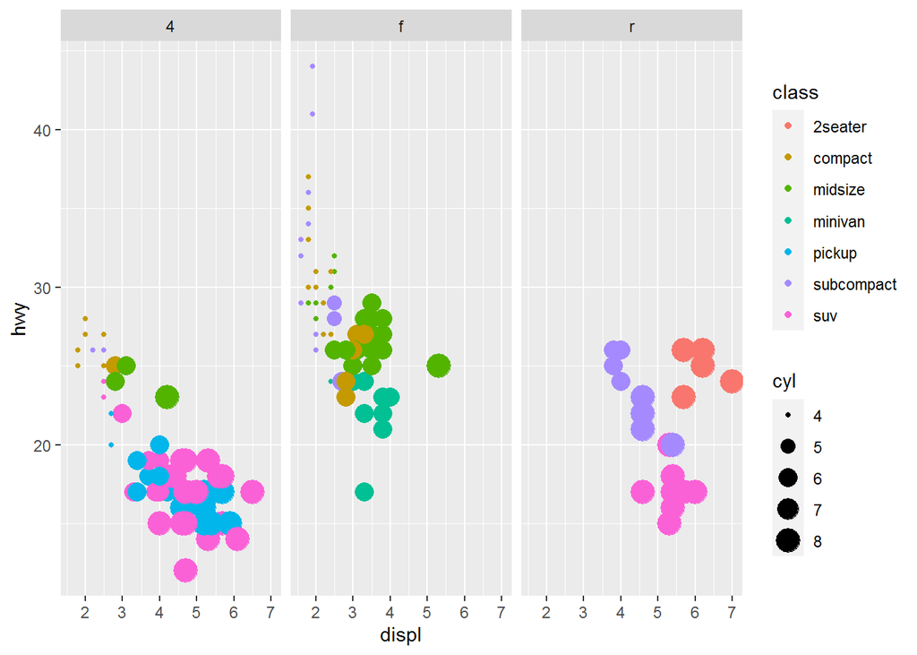

```r
ggplot(data = mpg) +
    geom_point(mapping = aes(x = displ, y = hwy, size = cyl, color = class)) +
    facet_wrap(~ drv)
```

This plot shows the rear wheel drive cars (*drv = r*) possesse a number of cylinders greater than or equal to 6 and fall into three class categories (suv, subcompact and 2seater)

```r
mpg %>%
    filter(drv == 'r') %>%
    distinct(class)
```

```
## # A tibble: 3 x 1
##   class
##   <chr>
## 1 suv
## 2 2seater
## 3 subcompact
```